# Project

# intro

This data sets are the result of a body sensor data collection by PUC-RIO researchers. The objective is to identify the final 20 classes in the data.test subset.

# data

The data is already split into train and test, where test data lacks the classes for it observations. This requires some detailed analysis before the final results.

```r
# load data
data.test <- read.csv("pml-testing.csv")

data.train <- read.csv("pml-training.csv")

# load libs
library(caret) # for modelling
```

```r
library(ggplot2) # for graphs
library(dplyr) # some wrangling
library(corrplot) # correlation matrix
```

## data cleaning and compression

The number of variables are overwhelming while the number of NAs is prohibitive. Here we shall reduce the number of variables in order to achieve a more tidy data and then, perform data compression via PCA.

The following will be done:

- Variable with more than 0% of NAs will be removed
- Categorical and Numeric variables will be split up

This second approach is useful for models that don’t deal very well with factors.

Also, for better performance I will subsample the data.train in a smaller, but representative, dataset.

```r
# subsample data.train for better performance
s <- sample(nrow(data.train), 1e4)

data.train <- data.train[s,]

# identify cols with too much nas and remove them
s <- sapply(data.train, function(t) {
    sum(is.na(t)) / length(t)
    })

s <- which(s > 0)

data.train <- data.train[, c(-s, -1)]
    # I also removed the variable X since it was causing trouble to some models

# split dataframe into categorical and numeric
s <- sapply(data.train, is.numeric)

data.train.cat <- data.train[, !s] # categorical
data.train.num <- data.train[, s] # numerical

# do it as well with the test data
s <- intersect(names(data.train),
           names(data.test))

data.test <- data.test[, s]

s <- sapply(data.test, is.numeric)

data.test.cat <- data.test[, !s]
data.test.num <- data.test[, s]
```

## exploratory analysis

We are looking for some correlation and classification potential for each variable. PCA, as data compression tool, is very useful for this very analysis. But first, let us explore the raw data.

cor and corrplot are useful for such visualization. I will also reduce the correlations to a cutoff of .6 due to the overwhelming number of variables.

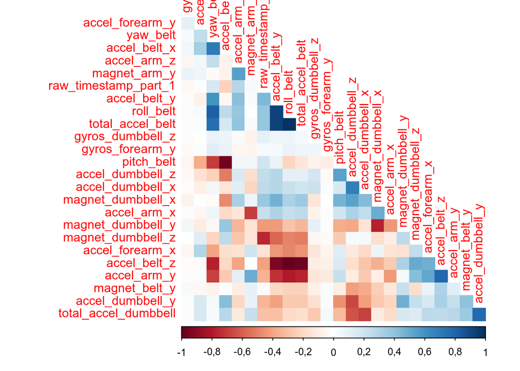

```r
# correlation matrix
c <- cor(data.train.num)

s <- findCorrelation(x = c, cutoff = .6)

corrplot(c[s,s],
     type = "lower",
     method = "color",
     diag = FALSE,
     order = "hclust")
```

The correlation matrices suggest that some variables are highly correlated (both positively or negatively) while others are nearly independent.

```r
# convert data into pca
data.train.pca <- prcomp(data.train.num, scale = TRUE)

# evaluate variability
data.frame(pca = colnames(data.train.pca$x),
       var = data.train.pca$sdev**2 / sum(data.train.pca$sdev**2),
       acc = cumsum(data.train.pca$sdev**2 / sum(data.train.pca$sdev**2)))
```

| pca | var | acc |
| --- | --- | --- |
| PC1 | 1,583658e-01 | 0,1583658 |
| PC2 | 1,492902e-01 | 0,3076561 |
| PC3 | 8,990082e-02 | 0,3975569 |
| PC4 | 6,837930e-02 | 0,4659362 |
| PC5 | 5,857271e-02 | 0,5245089 |
| PC6 | 4,245498e-02 | 0,5669639 |
| PC7 | 3,885709e-02 | 0,6058210 |
| PC8 | 3,739768e-02 | 0,6432186 |
| PC9 | 3,161024e-02 | 0,6748289 |
| PC10 | 3,141050e-02 | 0,7062394 |

[output cut: 45 more lines]

The PCA as unable to compress the data efficiently and let too much variation around with 90% of the variation around PC20 (of 55). But PCA still can be used for both the model and visualization.

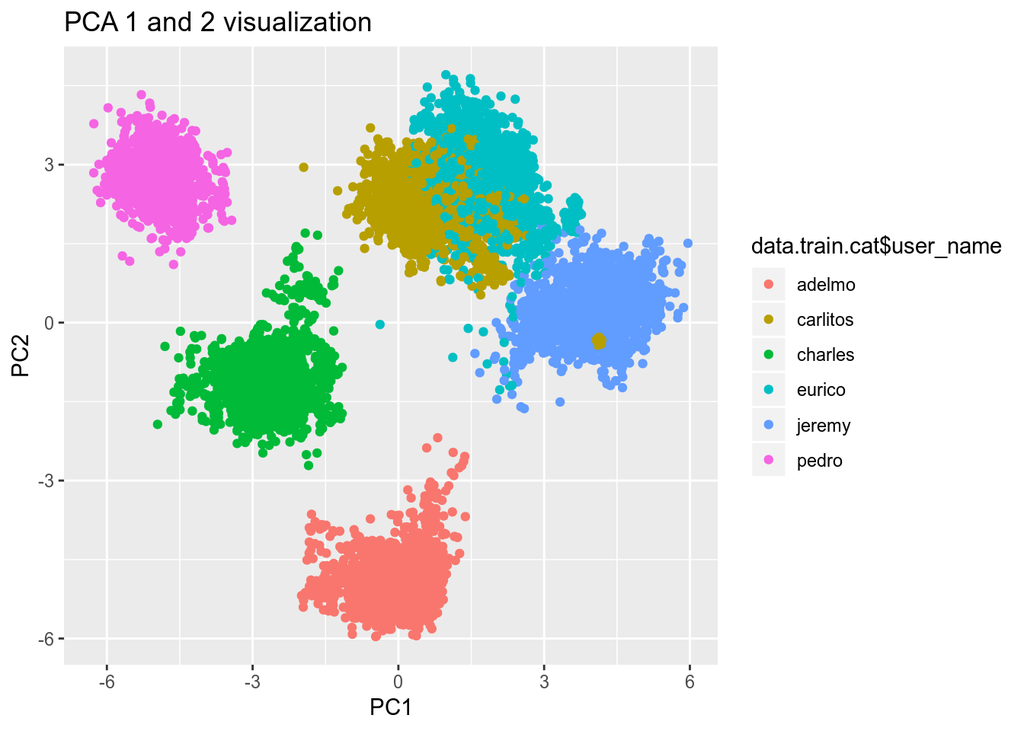

```r
qplot(data = data.frame(data.train.pca$x),
      x = PC1,
      y = PC2,
      colour = data.train.cat$user_name,
      main = "PCA 1 and 2 visualization")
```

PCA has found some segmentation within the data, it was able to segment the data according the the user, but not according to the activity.